# My Portfolio for Computational Musicology 2025

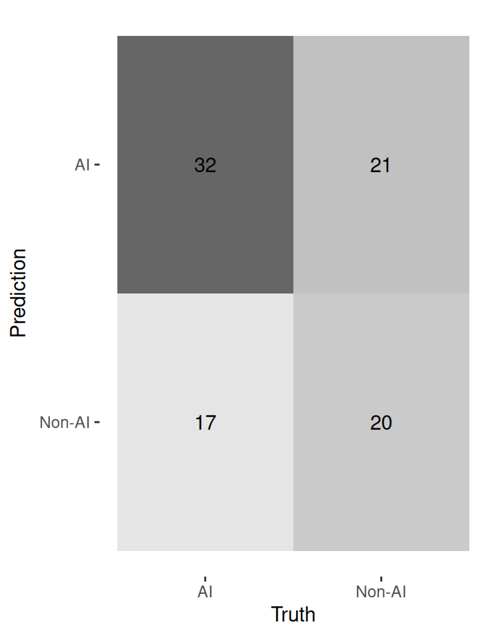

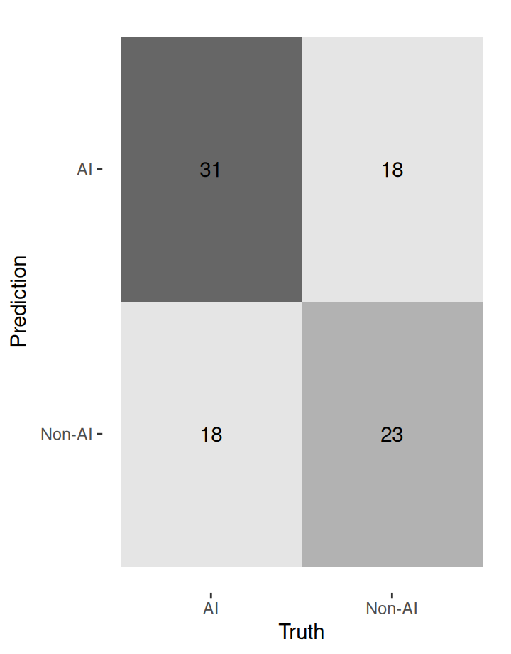

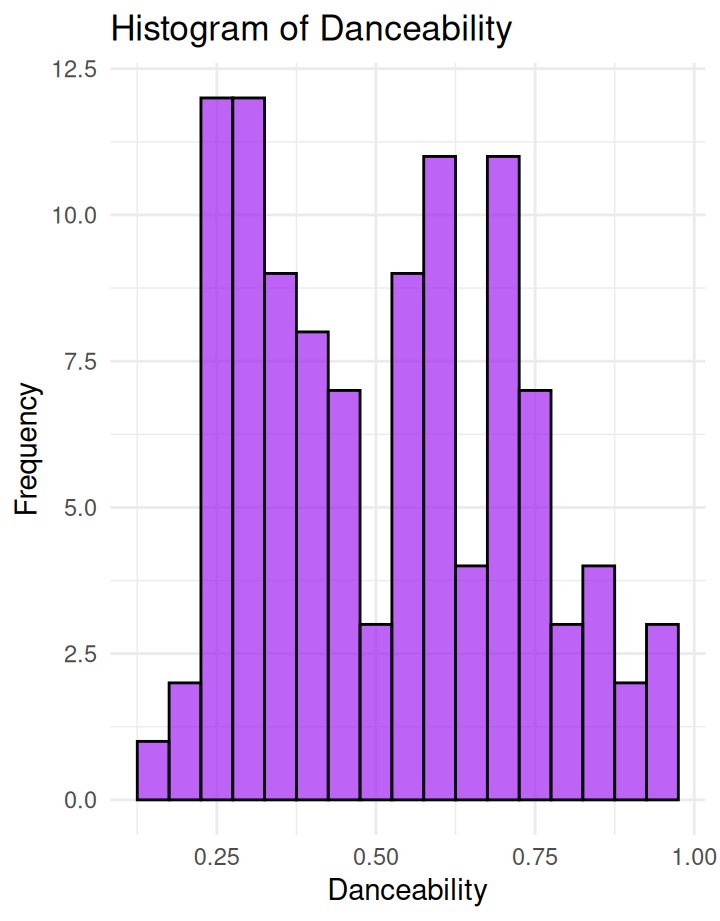

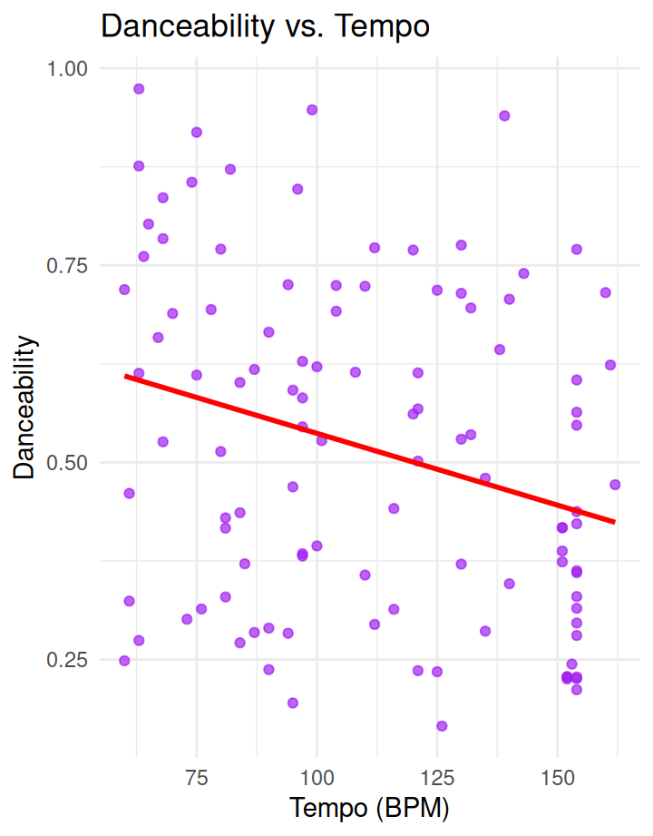

[figure not shown]

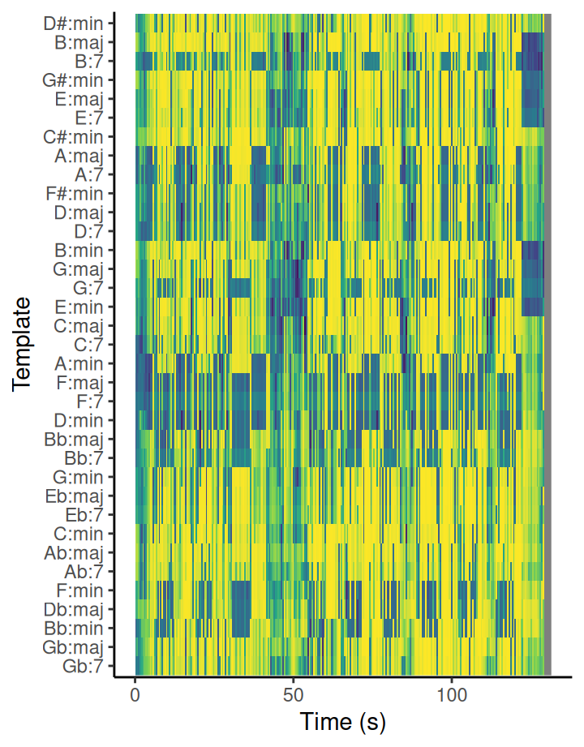

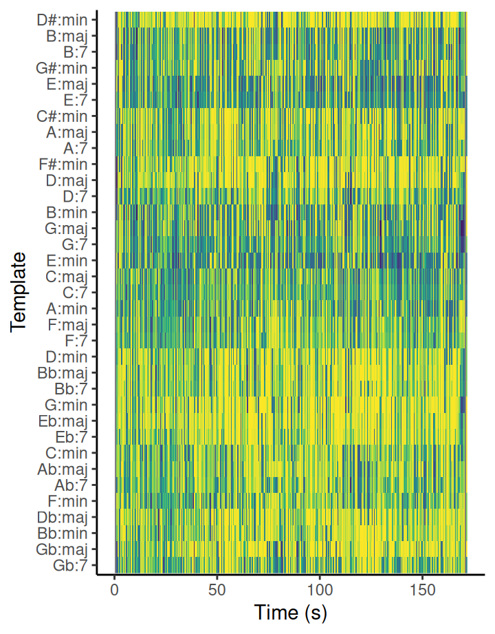

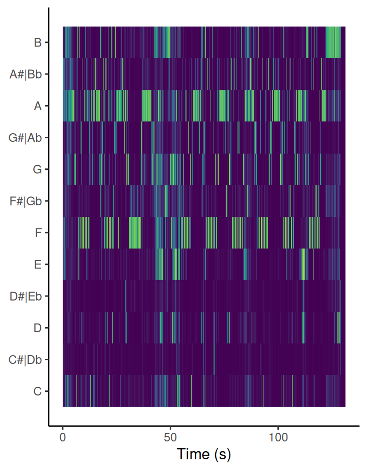

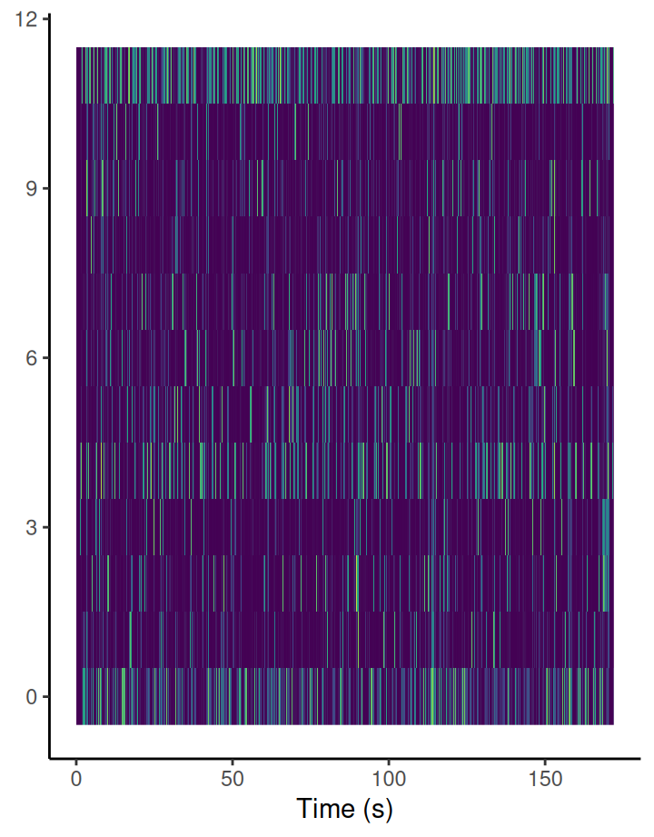

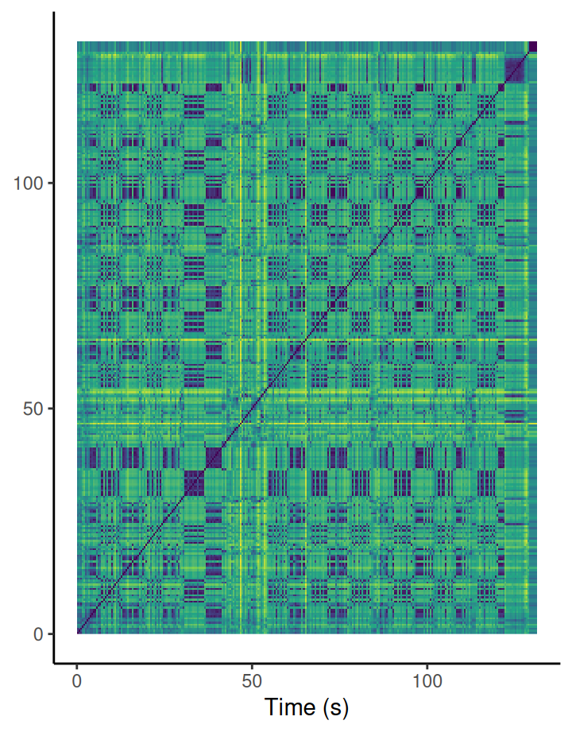

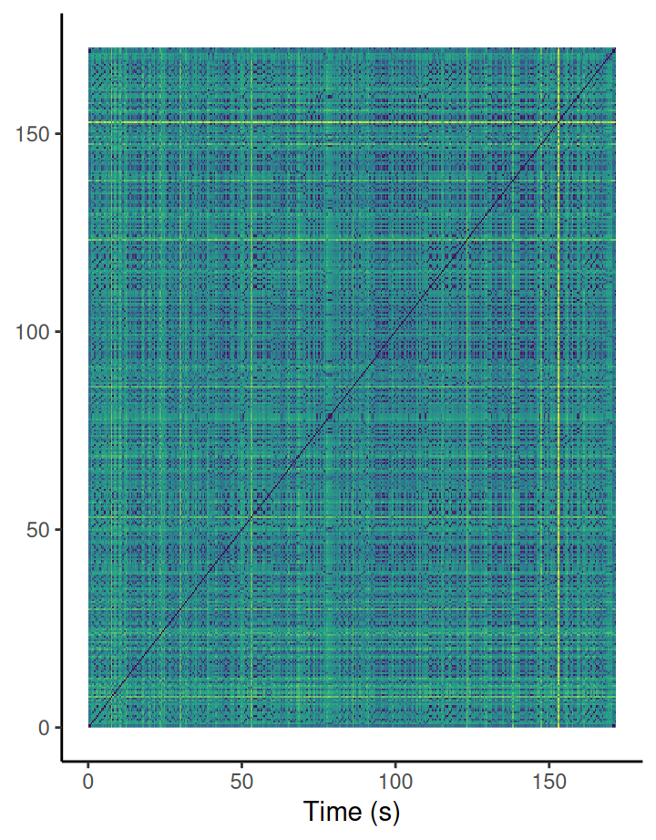

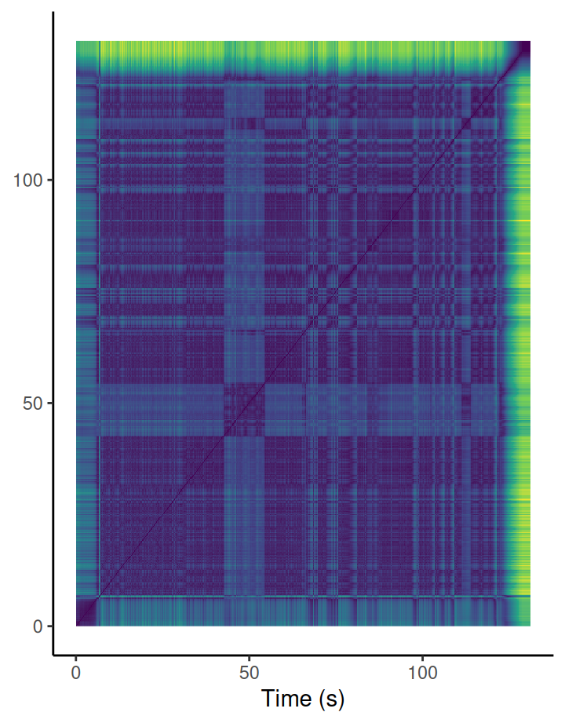

[3 more figures not shown]

# Visualizing the predicting power

## Column {data-width = 1100}

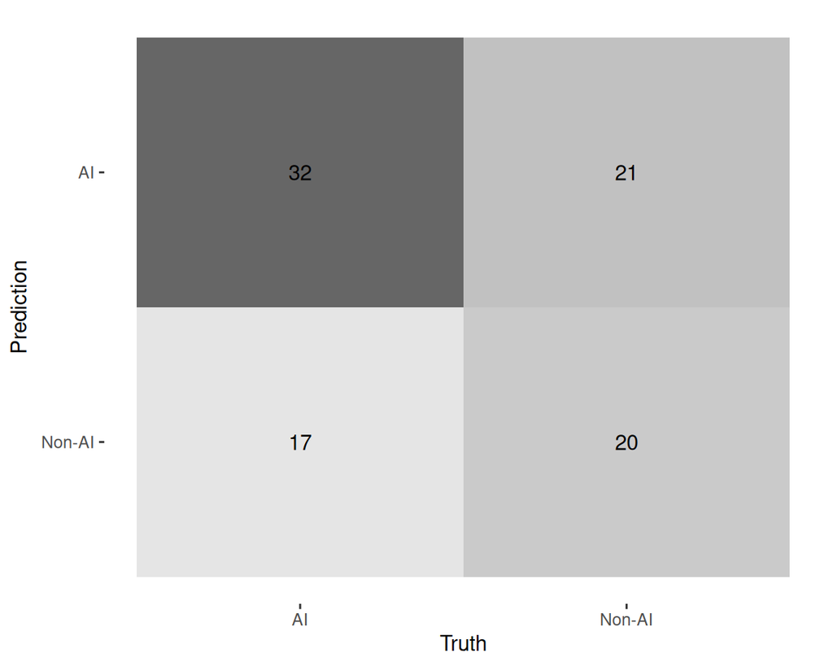

```r
indie_forest |> get_pr()
```

```
# A tibble: 2 × 3
  class  precision recall
  <fct>      <dbl>  <dbl>
1 AI         0.604  0.653
2 Non-AI     0.541  0.488
```

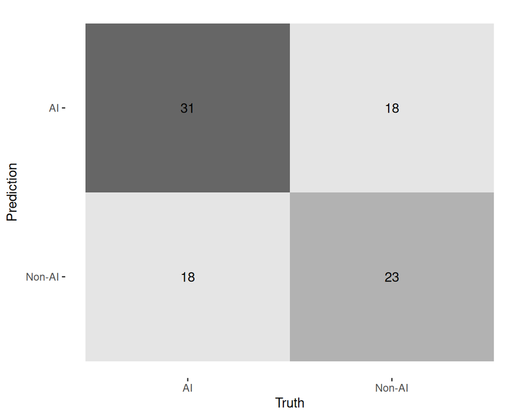

```r
forest_model <-
  rand_forest() |>
  set_mode("classification") |>
  set_engine("ranger", importance = "impurity")
indie_forest <-
  workflow() |>
  add_recipe(classification_recipe) |>
  add_model(forest_model)

indie_forest_resampled <- indie_forest |>
  fit_resamples(compmus_cv, control = control_resamples(save_pred = TRUE))


indie_forest_resampled |> get_conf_mat() |> autoplot(type = "heatmap")
```

```r
indie_forest_resampled |> get_pr()
```

```
# A tibble: 2 × 3
  class  precision recall
  <fct>      <dbl>  <dbl>
1 AI         0.633  0.633
2 Non-AI     0.561  0.561
```

# Introduction

Later we’ll dive further into the songs, for now here are 2 descriptions of the songs.

The first song has a dark, atmospheric 80s-inspired synthwave beat with smooth R&B elements, like The Weeknd , moody, energetic, downtempo, its made with Udio.ai

The second song is dembow, reggaeton, cumbia, afro-latin fusion, rap, latin trap. It’s like summer song that will bring you the back to the summer, made with Suno.ai

# Discovery

#### description

First we have a few plots, so a better insight into the data can be created

The histogram of danceability shows that most songs are moderately danceable

The plots show us that a higher tempo does not indicate an higher danceability, more about this on the exclusive insights page.

This is an interactable chart, so if you hover above it you can see extra information. As can be seen from the chart the arousal is around the 4, this chart is very similar to the boxplot, except for valence we have arousal here. Again the arousal stays the same and you can see that the danceability varies a lot

## Column {data-width = 1100}

#### chart 1

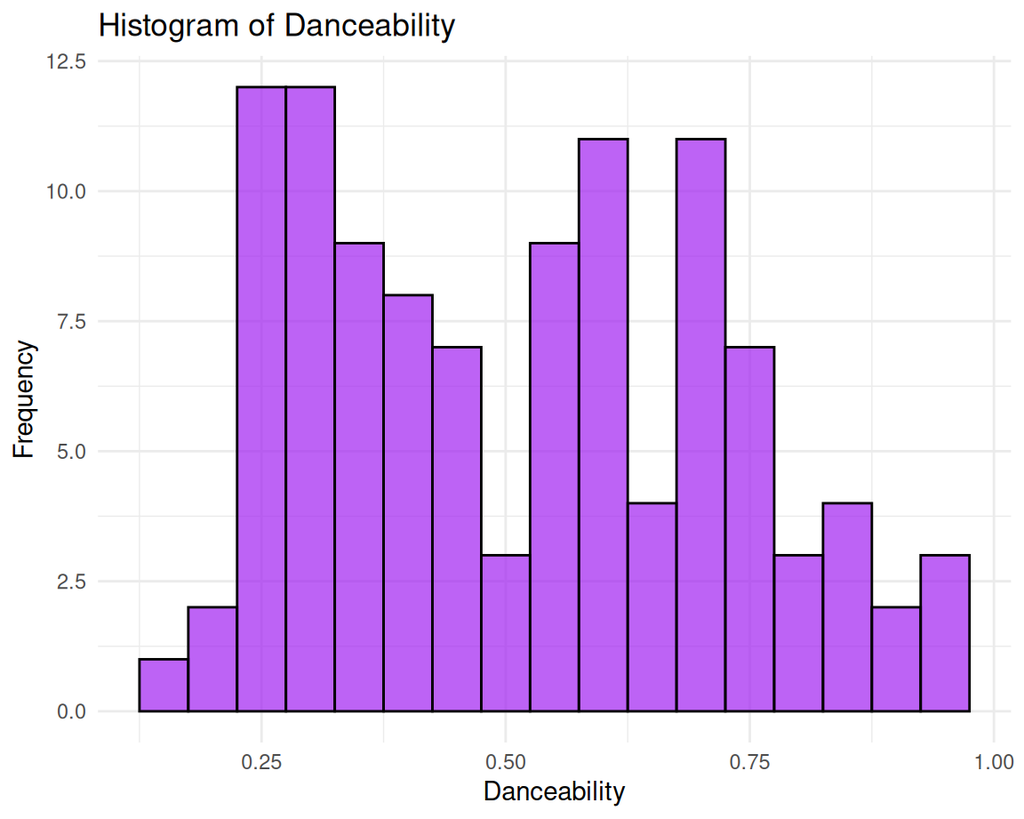

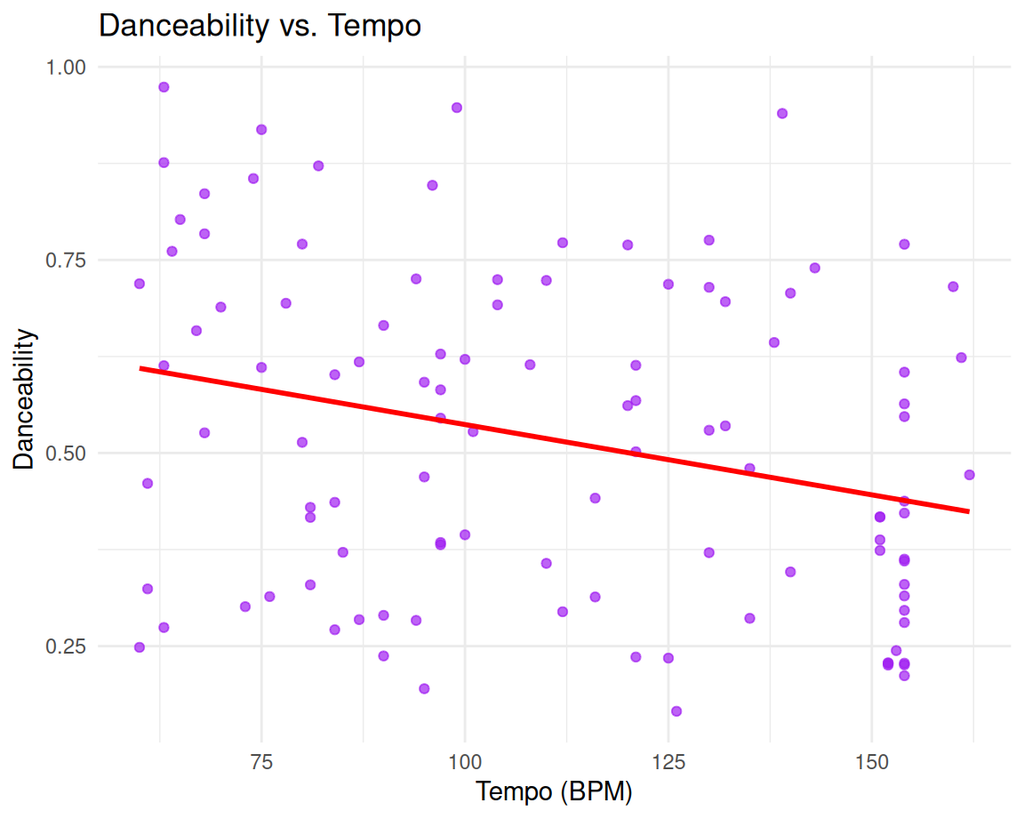

#### chart 2

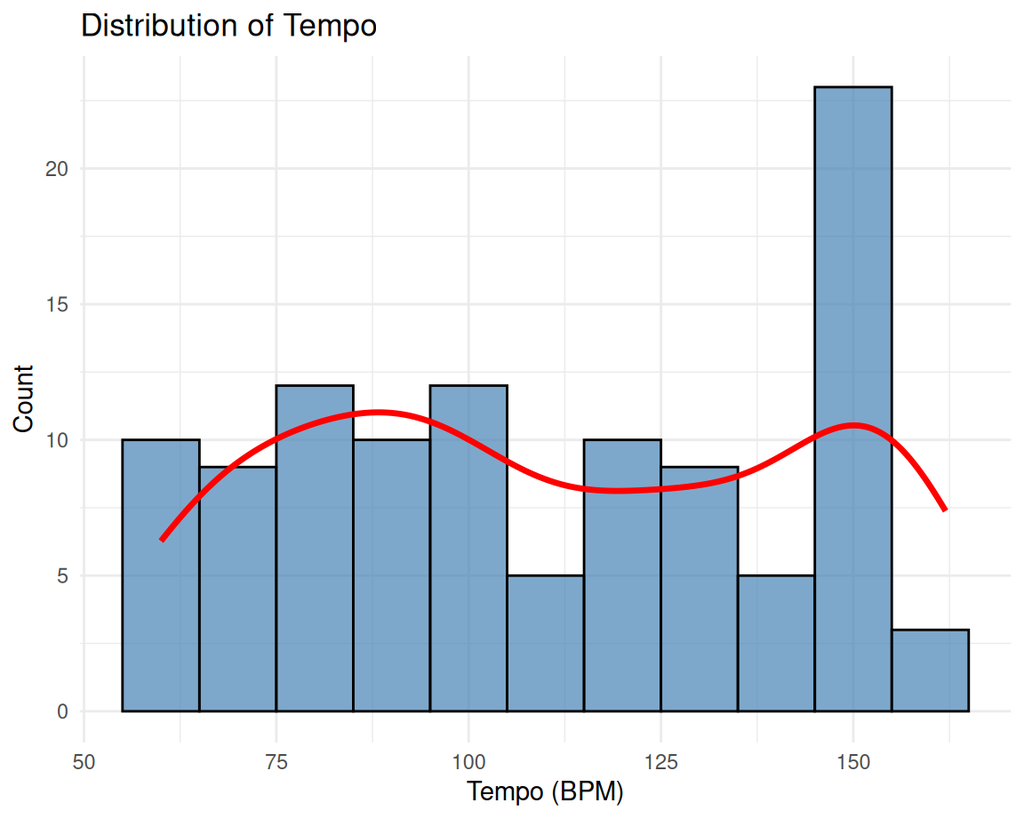

[figure not shown]

#### chart 3

[interactive chart not shown]

# Key profile

## Column {.sidebar data-width = 400}

#### Description

song 1 chord The frequent use of the seventh chord indicates a blues influence, as it’s used to add harmonic richness and tension. The repetition of chord sequences indicates the theme that is present in the whole song.

##### Song 1

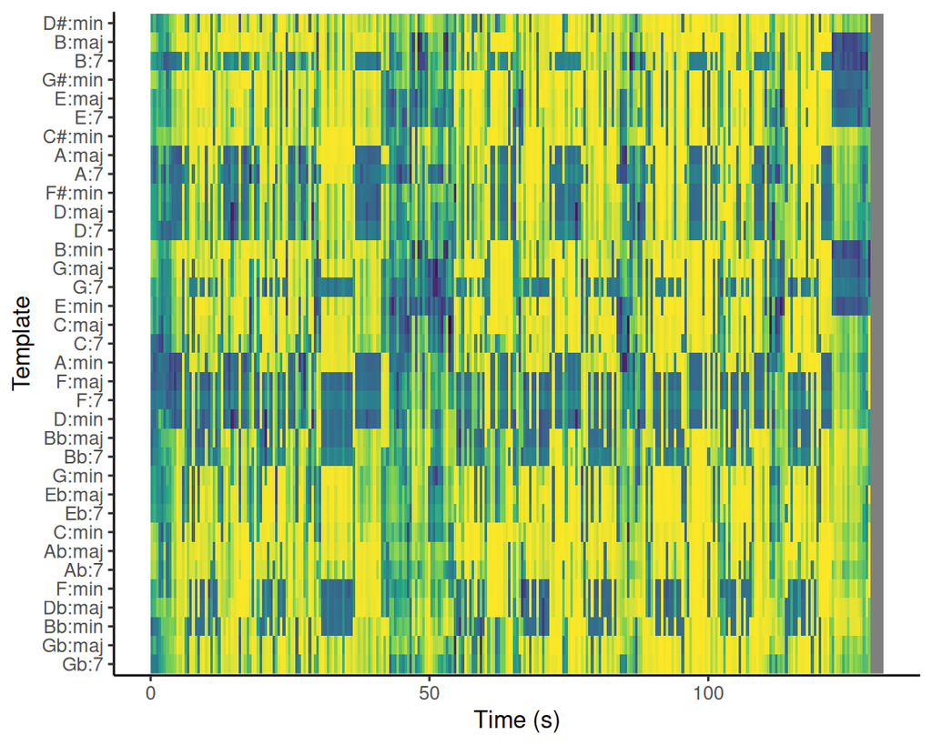

##### song 2

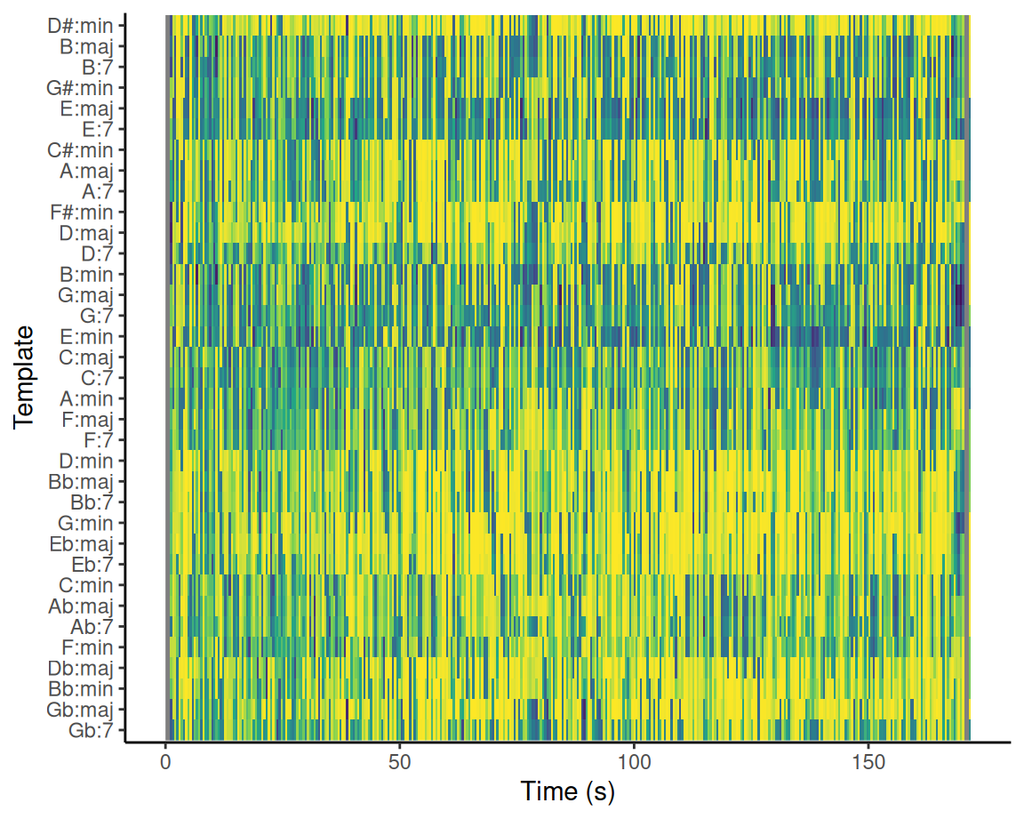

# Deep dive into the music

#### Description

self-similarity: It can be seen that the R&B track has a lot more similar parts in the song, as there are a lot of little black squares. This is because the clap and the synths are coming back with a repeated interval.

timbre-based similarity: The fist part of the song is in terms of similarity super similar until the chorus, and after its again very similar but there are also a bit more changes.

track 2 chroma : This song shows a sustained activity across all pitch classes. It shows that this song is more intricate and has a complexer harmonic progression

self-similarity: The latin track seems different but also the same, because it seems that the green lines are almost woven, this is because the beat is very similar but it has a sort of distortion above it.

timbre-based similarity: In the intro of this song it doesnt change much, but it does differ a lot from the rest of the song, the rest of the song has big chunks that are also simila except for the outro and a small part around 110 seconds.

## Column {data-width = 1100}

#### Chroma - Track 1

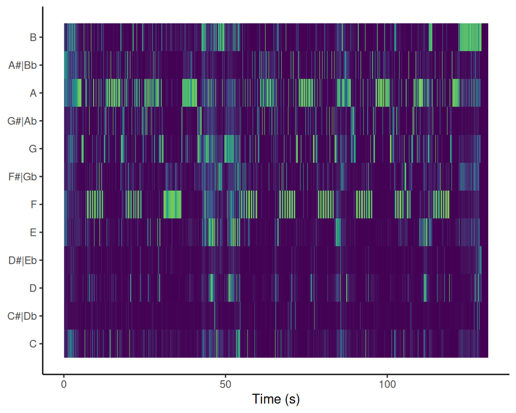

#### Chroma - Track 2

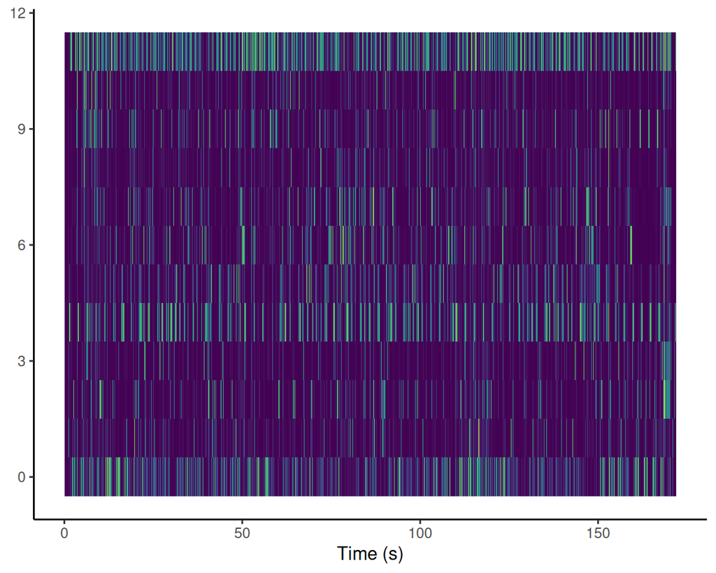

##### self-similarity track 1

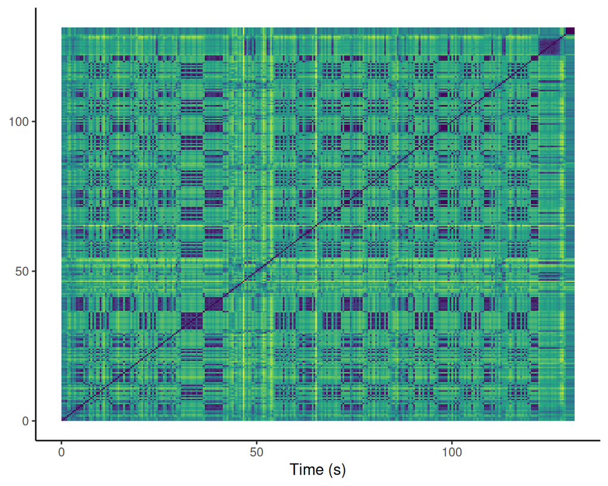

##### self-similarity track 2

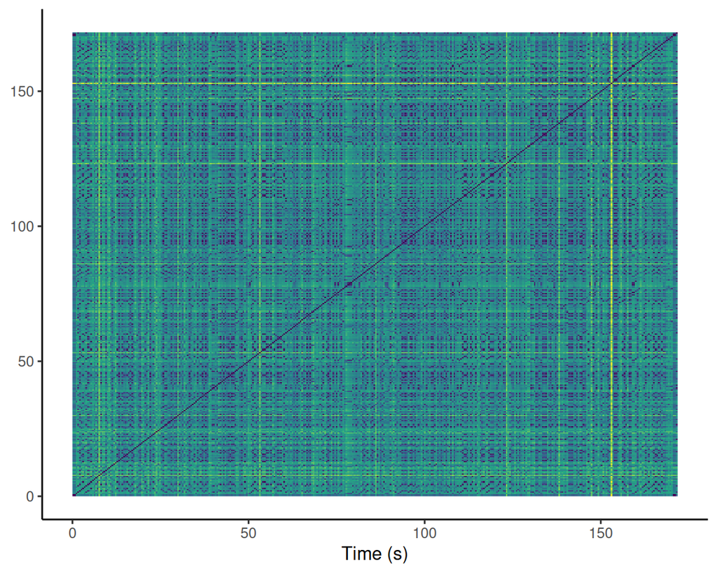

##### tibre based similarity track 1

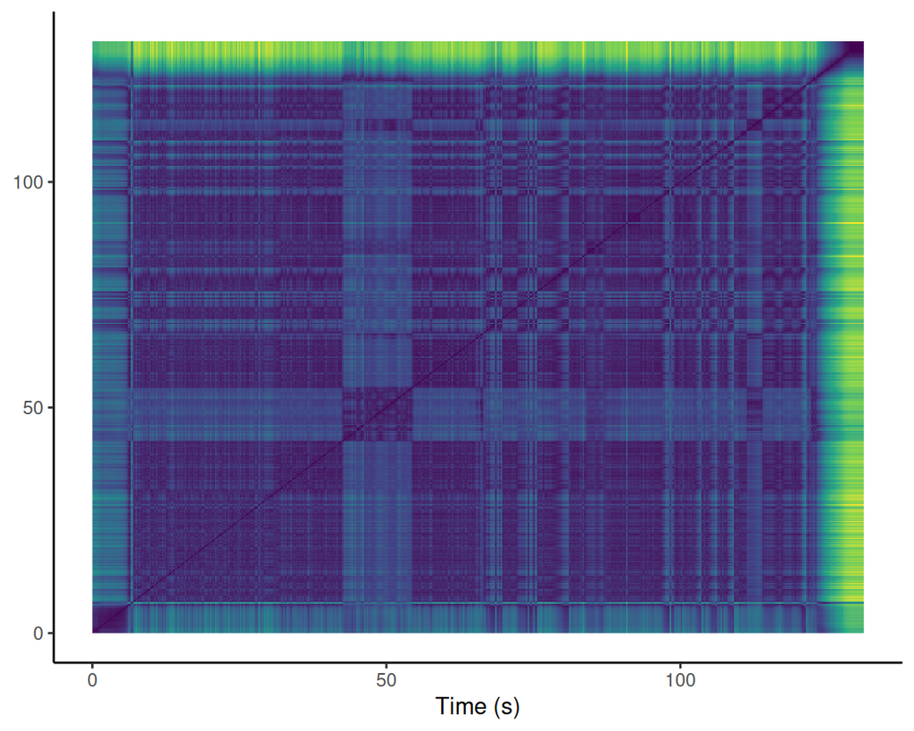

##### tibre based similarity track 2

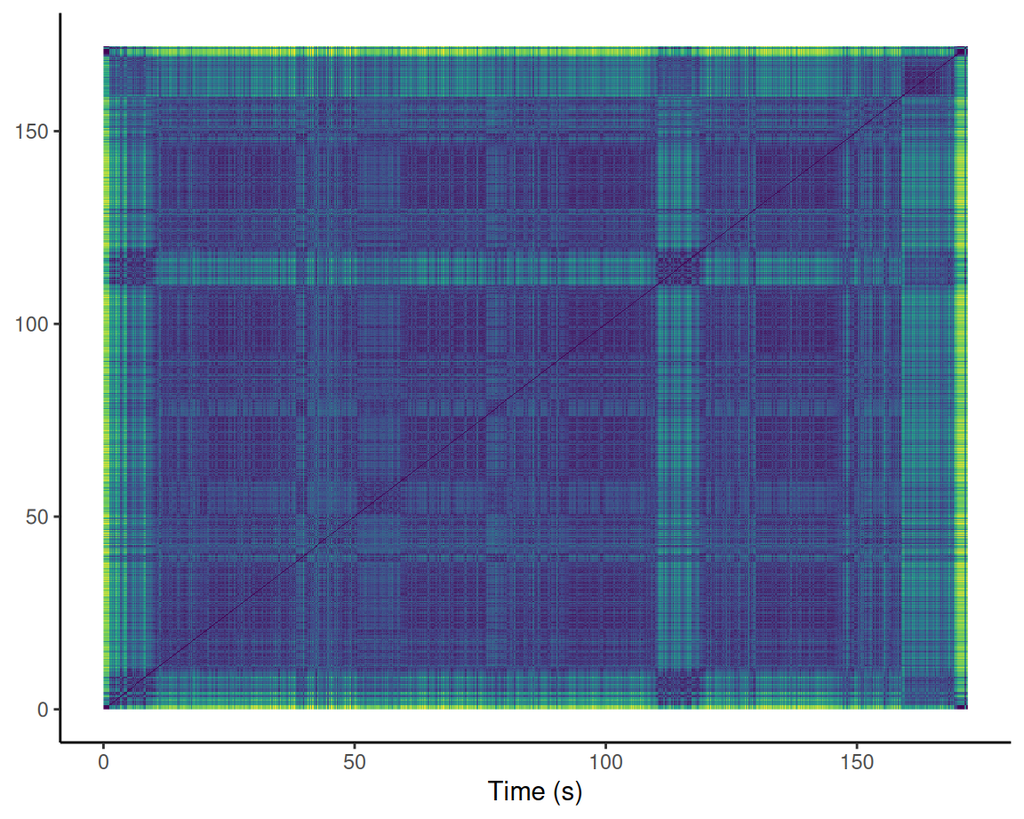

# Insights to the whole corpus

#### Description

The first song has 2 drops in tempo around 50 and 90 seconds, and in the outro the tempo also changes up a bit.

The second song’s tempo is almost the same till 110s and after 145seconds in the outro

For more info go to the exclusive insights

#### Tempi

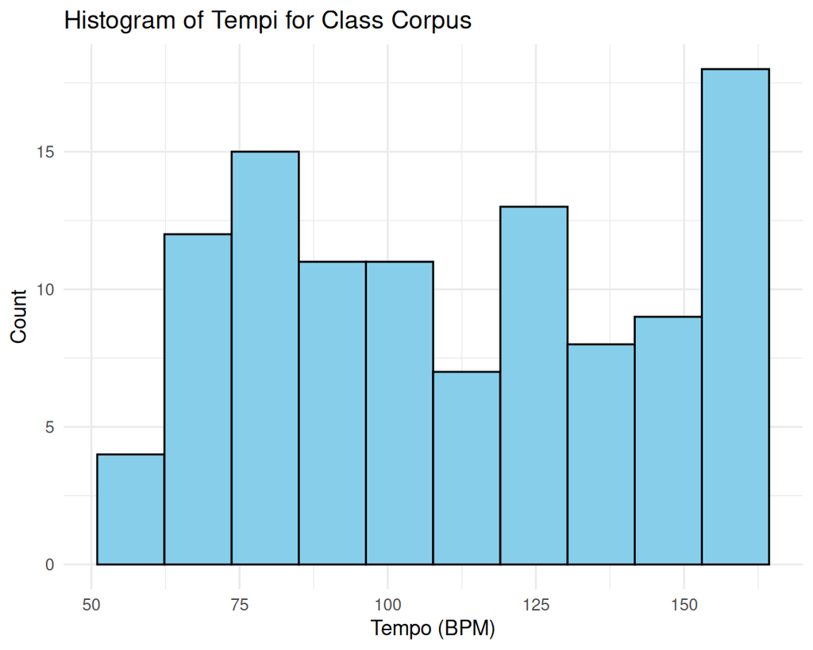

#### My contributions

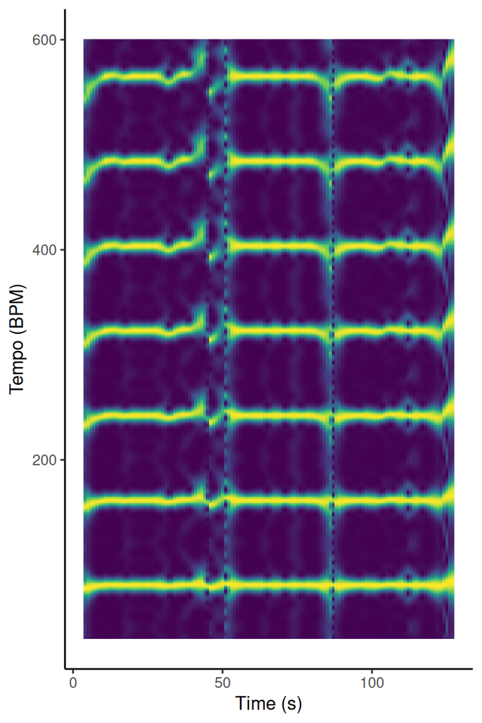

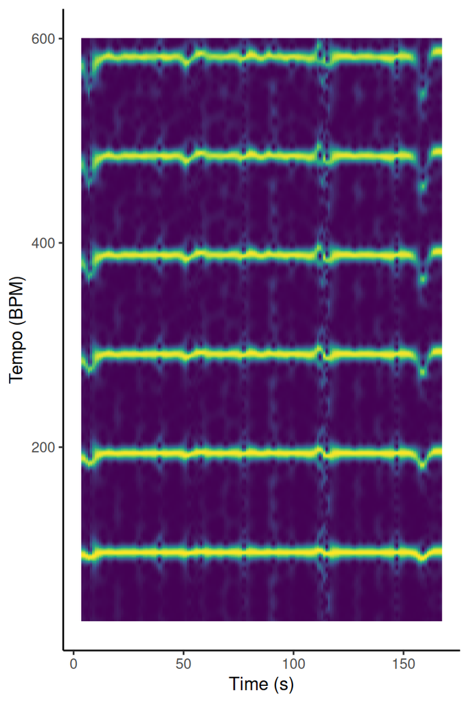

# Exclusive insights

While it seems shocking, danceability and tempo are not directly correlated, it’s among other things dependent on the rhythm, valence, instrumentation and arousal.

If you have a high tempo song, like an EDM song but with a bad rhythm it will not make it danceable, while if you have a slow song you could also slow dance on it and that will make it danceable. It’s also important how you define danceable, if its only jumping up and down then the plot would have to change. A song with a high tempo but low energy may not have the same danceable impact as a moderate-tempo track with high energy and rhythm.

Both songs have a very strong structure, this is because it’s AI generated and it probabily follows a formula to make a song.

When comparing the timbre-based self similarity matrix and the tempogram we can see that they show on similar places the difference.